# Digitalization in the workplace: Hidden cost of control? - Data Analysis

Mikhail Kudimov

December, 2022

This is an [R Markdown](http://rmarkdown.rstudio.com) notebook to demonstrate the data analysis process on the data obtained by the experiments within the project ‘Digitalization in the workplace: Hidden cost of control?’, namely ‘Differences in effort provision under automated control versus human control, a replication of Falk & Kosfeld 2006 in the context of Digital Economy’ academic research paper.

## Experiment 1

Load data for the experiment 1

```r
setwd(dirname(rstudioapi::getActiveDocumentContext()$path))
trust_df <- read.csv("data/trust.csv")
```

### Describe data

```r
ExpData(trust_df, type = 1)
```

| Descriptions | Value |
| --- | --- |
| Sample size (nrow) | 200 |
| No. of variables (ncol) | 114 |
| No. of numeric/interger variables | 42 |
| No. of factor variables | 0 |
| No. of text variables | 13 |
| No. of logical variables | 59 |
| No. of identifier variables | 7 |
| No. of date variables | 0 |
| No. of zero variance variables (uniform) | 31 |
| %. of variables having complete cases | 45.61% (52) |

[output cut: 3 more lines]

```r
ExpData(trust_df, type = 2)
```

| Index | Variable_Name | Variable_Type | Sample_n | Missing_Count | Per_of_Missing | No_of_distinct_values |
| --- | --- | --- | --- | --- | --- | --- |
| 1 | participant.id_in_session | integer | 200 | 0 | 0.00 | 200 |
| 2 | participant.code | character | 200 | 0 | 0.00 | 200 |
| 3 | participant.label | logical | 0 | 200 | 1.00 | 0 |
| 4 | participant._is_bot | integer | 200 | 0 | 0.00 | 1 |
| 5 | participant._index_in_pages | integer | 200 | 0 | 0.00 | 1 |
| 6 | participant._max_page_index | integer | 200 | 0 | 0.00 | 1 |
| 7 | participant._current_app_name | character | 200 | 0 | 0.00 | 1 |
| 8 | participant._current_page_name | character | 200 | 0 | 0.00 | 1 |
| 9 | participant.time_started_utc | character | 200 | 0 | 0.00 | 127 |
| 10 | participant.visited | integer | 200 | 0 | 0.00 | 1 |

[output cut: 104 more lines]

```r
ExpNumStat(trust_df, gp = "trust.1.group.minimum_amount", Outlier = TRUE, round = 2)
```

[output not shown]

[output cut: 2 more lines]

### Explore data

Plotting the categorical variables in the dataset

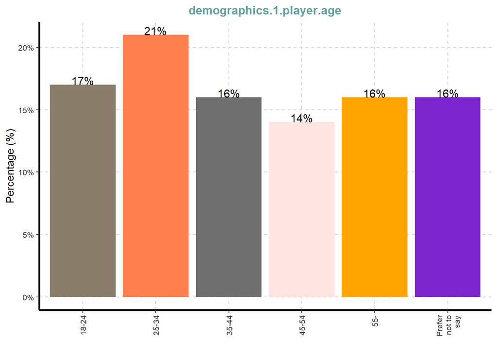

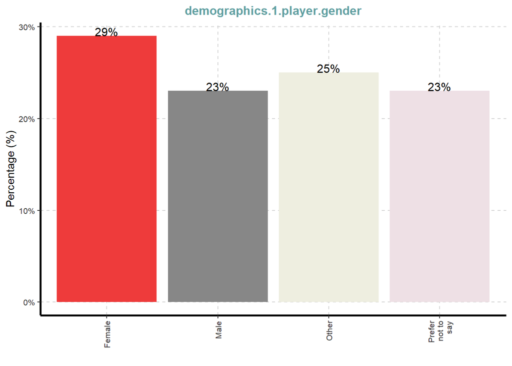

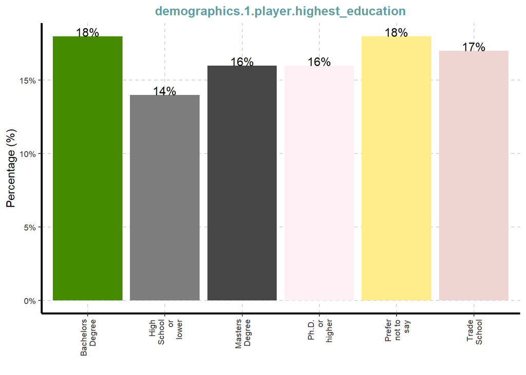

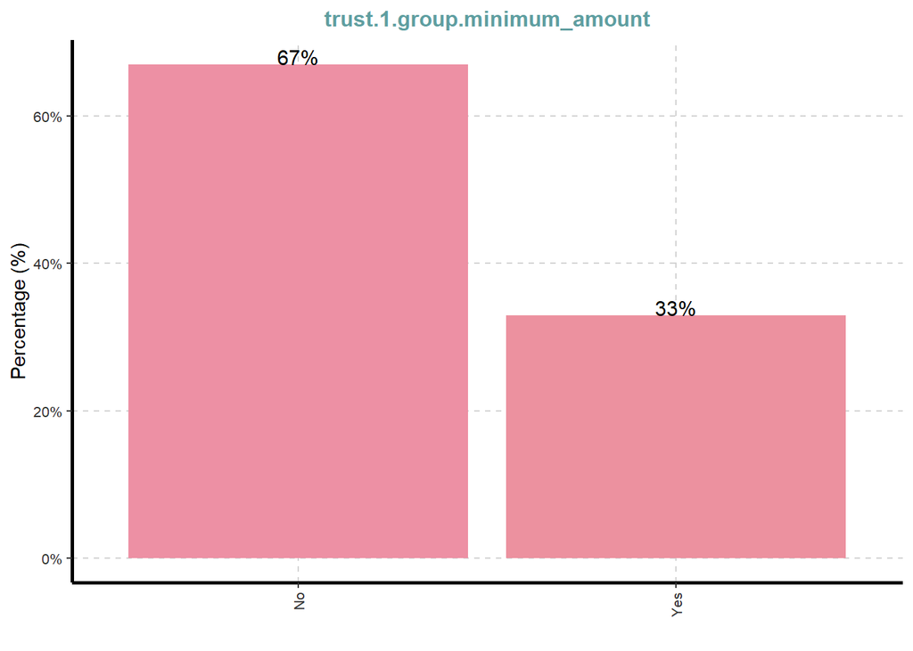

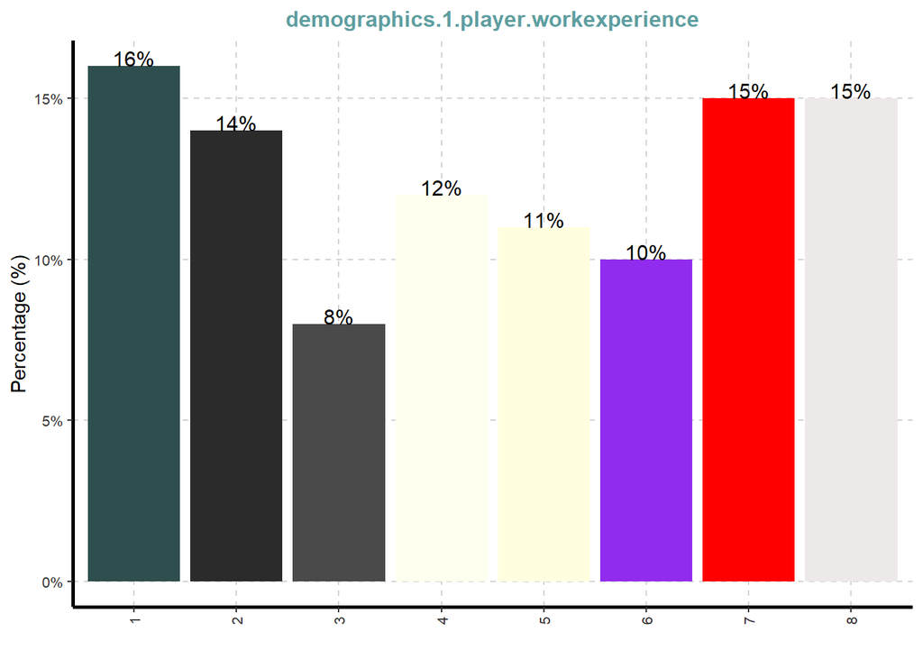

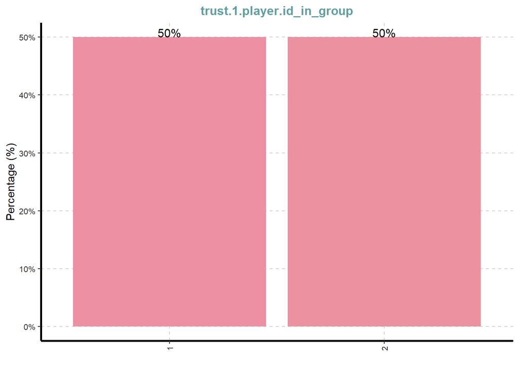

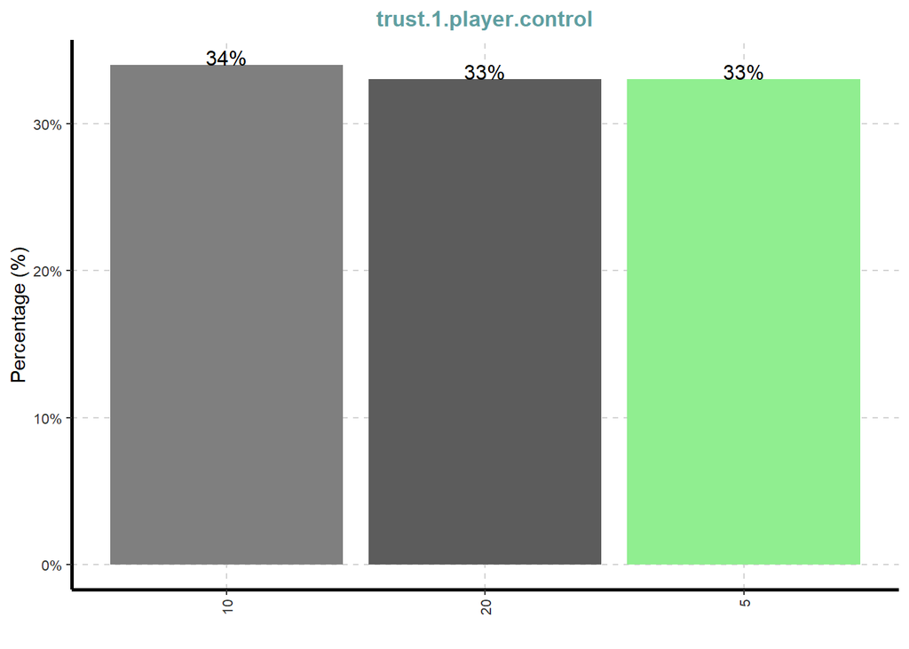

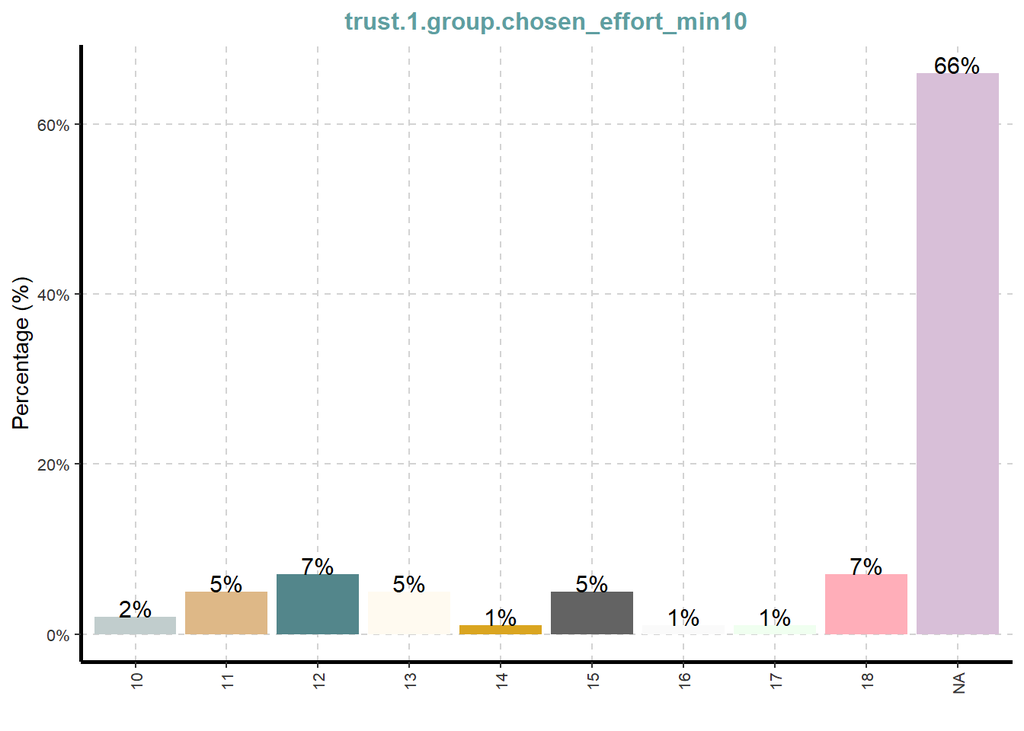

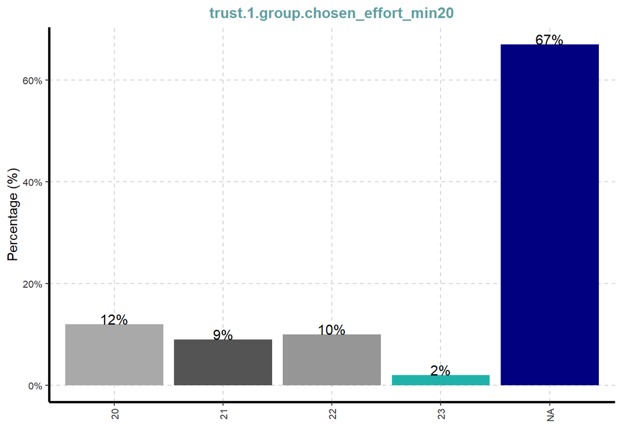

```r
ExpCatViz(trust_df)
```

Some insight that can be drawn:

Let us see the how the chosen effort average is distributed along the age groups:

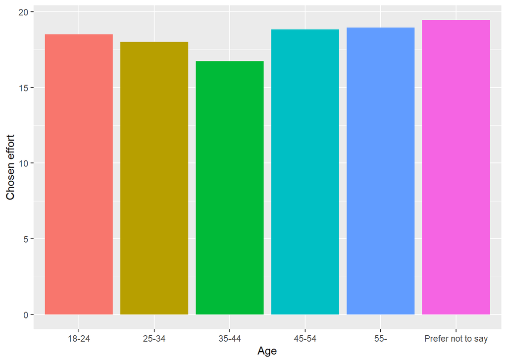

```r
df_demographics <- trust_df %>%
  select(c(demographics.1.player.age,demographics.1.player.highest_education, demographics.1.player.gender, demographics.1.player.workexperience, trust.1.group.chosen_effort))

ggplot(df_demographics) +
  geom_bar(aes(x=demographics.1.player.age, y=trust.1.group.chosen_effort, fill = as.factor(demographics.1.player.age)),
           position = "dodge", stat = "summary", fun = "mean") +
  labs(x = "Age", y = "Chosen effort") +
  theme(legend.position="none")
```

We can notice that age group 35-44 showed below average mean choice of effort level.

Let’s have a look at the distribution of chosen effort across highest achieved education by participant:

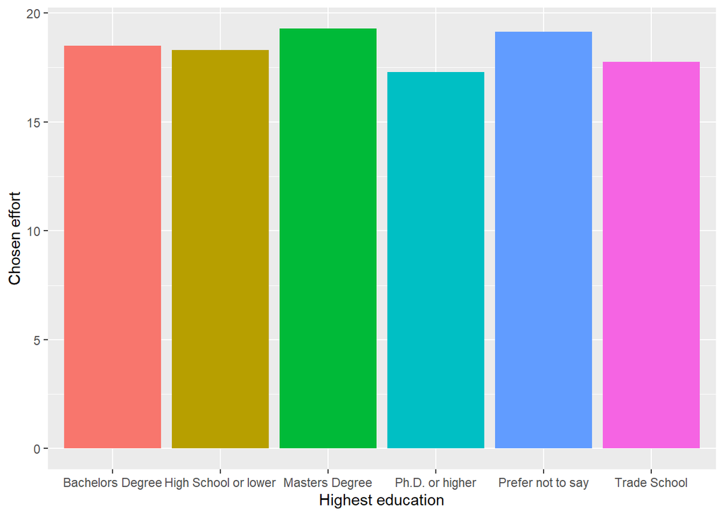

```r
ggplot(df_demographics) +
  geom_bar(aes(x=demographics.1.player.highest_education, y=trust.1.group.chosen_effort, fill = as.factor(demographics.1.player.highest_education)),
           position = "dodge", stat = "summary", fun = "mean") +
  labs(x = "Highest education", y = "Chosen effort") +
  theme(legend.position="none")
```

No notable differences are present here except that ‘Ph.D. or higher’ respondents had a lower chosen effort mean by a few points.

Analyzing the same differences per gender, gender ‘Other’ shows a slightly higher chosen effort mean.

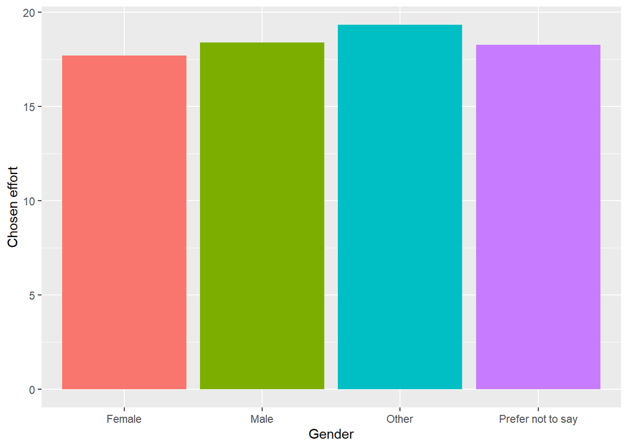

```r
ggplot(df_demographics) +
  geom_bar(aes(x=demographics.1.player.gender, y=trust.1.group.chosen_effort, fill = as.factor(demographics.1.player.gender)),
           position = "dodge", stat = "summary", fun = "mean") +
  labs(x = "Gender", y = "Chosen effort") +
  theme(legend.position="none")
```

Next up, we can see that participants with between 1 and 2 years of work experience show most mean effort provision.

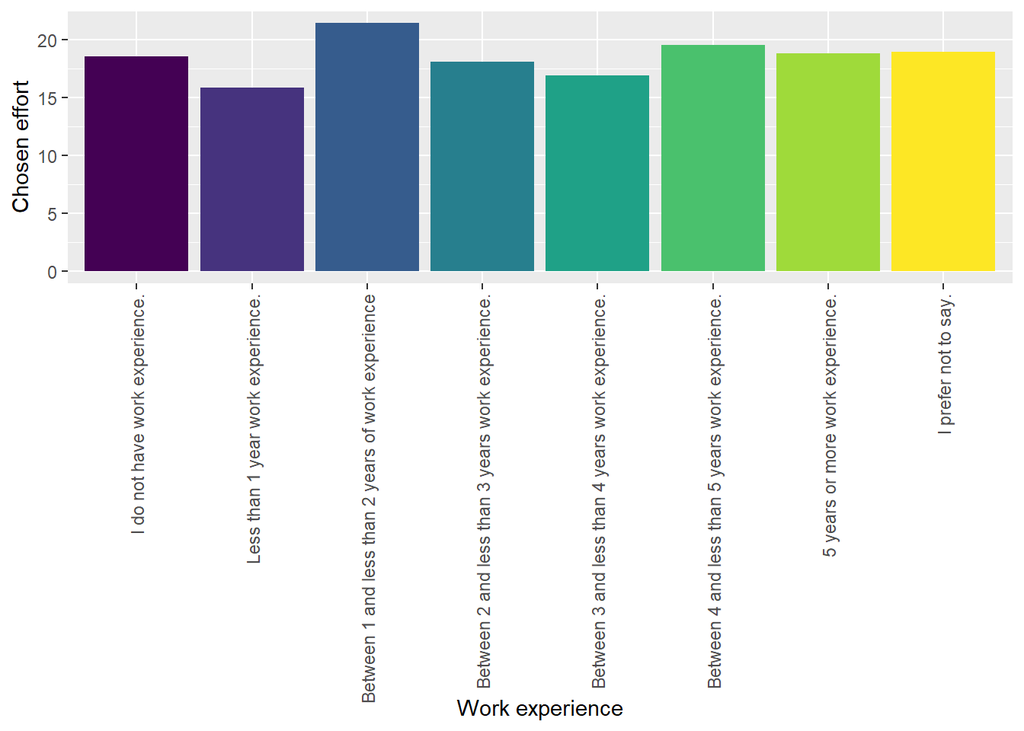

```r
factors_vector = c(
  "I do not have work experience.",
  "Less than 1 year work experience.",
  "Between 1 and less than 2 years of work experience",
  "Between 2 and less than 3 years work experience.",
  "Between 3 and less than 4 years work experience.",
  "Between 4 and less than 5 years work experience.",
  "5 years or more work experience.",
  "I prefer not to say."
  )
factors_df <- data.frame(V1=1:8, V2=factors_vector)

df_demographics <- within(df_demographics, {
  f <- factor(df_demographics$demographics.1.player.workexperience, levels=factors_df$V1, labels=factors_df$V2)
  demographics.1.player.workexperience <- as.character(f)
  })

df_demographics$demographics.1.player.workexperience <- as.character(df_demographics$demographics.1.player.workexperience)
df_demographics$demographics.1.player.workexperience <- ordered(df_demographics$demographics.1.player.workexperience, levels = factors_vector)

ggplot(df_demographics) +
  geom_bar(aes(x=demographics.1.player.workexperience, y=trust.1.group.chosen_effort, fill = as.factor(demographics.1.player.workexperience)),
           position = "dodge", stat = "summary", fun = "mean") +
  labs(x = "Work experience", y = "Chosen effort") +
  theme(legend.position="none") +
  theme(axis.text.x = element_text(angle = 90, vjust = 0.5, hjust=1))
```

### Prepare data

Since the participants are split into principal/agent pairs, the dataset contains information about experiment values (chosen effort if not controlled, effort if controlled) in both rows - for the principal and the agent, essentially duplicating these data.

```r
head(trust_df)
```

|  | participant.id_in_session | participant.code | participant.label | participant._is_bot | participant._index_in_pages | participant._max_page_index | participant._current_app_name | participant._current_page_name | participant.time_started_utc | participant.visited | participant.mturk_worker_id | participant.mturk_assignment_id | participant.payoff | participant.random_treatment_ids | session.code | session.label | session.mturk_HITId | session.mturk_HITGroupId | session.comment | session.is_demo | session.config.name | session.config.real_world_currency_per_point | session.config.participation_fee | session.params | informed_consent.1.player.id_in_group | informed_consent.1.player.role | informed_consent.1.player.payoff | informed_consent.1.player.consent_given | informed_consent.1.group.id_in_subsession | … |
| --- | --- | --- | --- | --- | --- | --- | --- | --- | --- | --- | --- | --- | --- | --- | --- | --- | --- | --- | --- | --- | --- | --- | --- | --- | --- | --- | --- | --- | --- | --- |
| 1 | 1 | kpxpeg88 | NA | 0 | 13 | 13 | payment_info | PaymentInfo | 42:30.0 | 1 | NA | NA | 30 | NA | mrg9wqem | NA | NA | NA | NA | 0 | trust | 0.01 | 0.25 | NA | 1 | NA | 0 | 1 | 1 | … |
| 2 | 2 | sho4g59v | NA | 0 | 13 | 13 | payment_info | PaymentInfo | 42:32.0 | 1 | NA | NA | 105 | NA | mrg9wqem | NA | NA | NA | NA | 0 | trust | 0.01 | 0.25 | NA | 2 | NA | 0 | 1 | 1 | … |
| 3 | 3 | p8z0ie6g | NA | 0 | 13 | 13 | payment_info | PaymentInfo | 44:11.7 | 1 | NA | NA | 40 | NA | mrg9wqem | NA | NA | NA | NA | 0 | trust | 0.01 | 0.25 | NA | 3 | NA | 0 | 1 | 1 | … |
| 4 | 4 | qf5p02l3 | NA | 0 | 13 | 13 | payment_info | PaymentInfo | 44:12.1 | 1 | NA | NA | 100 | NA | mrg9wqem | NA | NA | NA | NA | 0 | trust | 0.01 | 0.25 | NA | 4 | NA | 0 | 1 | 1 | … |
| 5 | 5 | 34xzv5p2 | NA | 0 | 13 | 13 | payment_info | PaymentInfo | 45:09.9 | 1 | NA | NA | 24 | NA | mrg9wqem | NA | NA | NA | NA | 0 | trust | 0.01 | 0.25 | NA | 5 | NA | 0 | 1 | 1 | … |
| 6 | 6 | p6wjkl3r | NA | 0 | 13 | 13 | payment_info | PaymentInfo | 45:10.6 | 1 | NA | NA | 108 | NA | mrg9wqem | NA | NA | NA | NA | 0 | trust | 0.01 | 0.25 | NA | 6 | NA | 0 | 1 | 1 | … |

Let us then have only agent rows in a separate dataframe

```r
trust_df_agent <- trust_df %>%
  filter(participant.id_in_session %% 2 == 0)
```

Apart from that, let’s separate each treatment into a dataframe for convenience

```r
trust_c5 <- trust_df_agent %>%
  filter(!is.na(trust.1.group.chosen_effort_min5))

trust_c10 <- trust_df_agent %>%
  filter(!is.na(trust.1.group.chosen_effort_min10))

trust_c20 <- trust_df_agent %>%
  filter(!is.na(trust.1.group.chosen_effort_min20))
```

Thus, in each dataframe, `trust.1.group.chosen_effort` is the chosen effort if no minimum amount is set and `trust.1.group.chosen_effort_min5` , `trust.1.group.chosen_effort_min10` and `trust.1.group.chosen_effort_min20` is the chosen effort if the minimum amount is set for treatments C5, C10 and C20, respectively.

### Analysis

In this section we will be aiming to conduct several tests to understand if hidden costs of control are present in the results of the this experiment. The significance level $\alpha$ here and further on is chosen to be 5%.

Firstly, we will test if there is difference in effort provision in cases of controlling and not controlling, with the null hypothesis being that the groups are the same. This will be done by modifying chosen effort in no control scenario to always be above minimum amount (setting all those that are lower to a minimum amount).

```r
trust_c5 <- trust_c5 %>%
  mutate(trust.1.group.chosen_effort_modified = ifelse(trust.1.group.chosen_effort < 5, 5, trust.1.group.chosen_effort))

test1_c5 <- data.frame(
  effort = c(trust_c5$trust.1.group.chosen_effort_min5, trust_c5$trust.1.group.chosen_effort_modified),
  group = factor(rep(c("control", "no control"), c(nrow(trust_c5), nrow(trust_c5))))
)

wilcox.test(trust_c5$trust.1.group.chosen_effort_min5, trust_c5$trust.1.group.chosen_effort_modified, data = test1_c5, paired = T, exact = F)
```

```
##
##  Wilcoxon signed rank test with continuity correction
##
## data:  trust_c5$trust.1.group.chosen_effort_min5 and trust_c5$trust.1.group.chosen_effort_modified
## V = 19, p-value = 2.881e-06
## alternative hypothesis: true location shift is not equal to 0
```

Let’s look at the means of groups.

```r
mean(trust_c5$trust.1.group.chosen_effort_min5)
```

```
## [1] 9.939394
```

```r
mean(trust_c5$trust.1.group.chosen_effort_modified)
```

```
## [1] 13.93939
```

We can see that, as expected, mean effort provision with no control is higher.

Let’s test the same hypothesis for C10 treatment:

```r
trust_c10 <- trust_c10 %>%
  mutate(trust.1.group.chosen_effort_modified = ifelse(trust.1.group.chosen_effort < 10, 10, trust.1.group.chosen_effort))

test1_c10 <- data.frame(
  effort = c(trust_c10$trust.1.group.chosen_effort_min10, trust_c10$trust.1.group.chosen_effort_modified),
  group = factor(rep(c("control", "no control"), c(nrow(trust_c10), nrow(trust_c10))))
)

wilcox.test(trust_c10$trust.1.group.chosen_effort_min10, trust_c10$trust.1.group.chosen_effort_modified, data = test1_c10, paired = T, exact = F)
```

```
##
##  Wilcoxon signed rank test with continuity correction
##
## data:  trust_c10$trust.1.group.chosen_effort_min10 and trust_c10$trust.1.group.chosen_effort_modified
## V = 24, p-value = 7.031e-06
## alternative hypothesis: true location shift is not equal to 0
```

Again, the null hypothesis is rejected.

Having look at the means, no control has greater mean effort provision.

```r
mean(trust_c10$trust.1.group.chosen_effort_min10)
```

```
## [1] 13.88235
```

```r
mean(trust_c10$trust.1.group.chosen_effort_modified)
```

```
## [1] 17.32353
```

Finally, test C20 treatment.

```r
trust_c20 <- trust_c20 %>%
  mutate(trust.1.group.chosen_effort_modified = ifelse(trust.1.group.chosen_effort < 20, 20, trust.1.group.chosen_effort))

test1_c20 <- data.frame(
  effort = c(trust_c20$trust.1.group.chosen_effort_min20, trust_c20$trust.1.group.chosen_effort_modified),
  group = factor(rep(c("control", "no control"), c(nrow(trust_c20), nrow(trust_c20))))
)

wilcox.test(trust_c20$trust.1.group.chosen_effort_min20, trust_c20$trust.1.group.chosen_effort_modified, data = test1_c20, paired = T, exact = F)
```

```
##
##  Wilcoxon signed rank test with continuity correction
##
## data:  trust_c20$trust.1.group.chosen_effort_min20 and trust_c20$trust.1.group.chosen_effort_modified
## V = 31.5, p-value = 9.218e-05
## alternative hypothesis: true location shift is not equal to 0
```

Again, we reject the null hypothesis.

The mean of effort provision is again greater for no control.

```r
mean(trust_c20$trust.1.group.chosen_effort_min20)
```

```
## [1] 21.06061
```

```r
mean(trust_c20$trust.1.group.chosen_effort_modified)
```

```
## [1] 24.09091
```

Now, let us conduct the second test for these treatments. We will be testing if the hidden costs of control outweigh the benefits. That is, if effort provision is greater for no control situations even if no adjustment with setting values lesser than minimum amount to minimum amount is implemented.

```r
# C5
wilcox.test(trust_c5$trust.1.group.chosen_effort_min5, trust_c5$trust.1.group.chosen_effort, paired = T, exact = F)
```

```
##
##  Wilcoxon signed rank test with continuity correction
##
## data:  trust_c5$trust.1.group.chosen_effort_min5 and trust_c5$trust.1.group.chosen_effort
## V = 19, p-value = 2.881e-06
## alternative hypothesis: true location shift is not equal to 0
```

```r
# C10
wilcox.test(trust_c10$trust.1.group.chosen_effort_min10, trust_c10$trust.1.group.chosen_effort, paired = T, exact = F)
```

```
##
##  Wilcoxon signed rank test with continuity correction
##
## data:  trust_c10$trust.1.group.chosen_effort_min10 and trust_c10$trust.1.group.chosen_effort
## V = 28, p-value = 1.006e-05
## alternative hypothesis: true location shift is not equal to 0
```

```r
# C20
wilcox.test(trust_c20$trust.1.group.chosen_effort_min20, trust_c20$trust.1.group.chosen_effort, paired = T, exact = F)
```

```
##
##  Wilcoxon signed rank test with continuity correction
##
## data:  trust_c20$trust.1.group.chosen_effort_min20 and trust_c20$trust.1.group.chosen_effort
## V = 52.5, p-value = 0.0002113
## alternative hypothesis: true location shift is not equal to 0
```

All tests show significant difference, meaning that in all treatments more effort is provided in case the principal trusts.

Indeed, looking at means and medians of these groups, in all treatments the no control decision yields greater effort.

```r
mean(trust_c5$trust.1.group.chosen_effort_min5)
```

```
## [1] 9.939394
```

```r
mean(trust_c5$trust.1.group.chosen_effort)
```

```
## [1] 13.93939
```

```r
median(trust_c5$trust.1.group.chosen_effort_min5)
```

```
## [1] 9
```

```r
median(trust_c5$trust.1.group.chosen_effort)
```

```
## [1] 14
```

```r
mean(trust_c10$trust.1.group.chosen_effort_min10)
```

```
## [1] 13.88235
```

```r
mean(trust_c10$trust.1.group.chosen_effort)
```

```
## [1] 17.29412
```

```r
median(trust_c10$trust.1.group.chosen_effort_min10)
```

```
## [1] 13
```

```r
median(trust_c10$trust.1.group.chosen_effort)
```

```
## [1] 18
```

```r
mean(trust_c20$trust.1.group.chosen_effort_min20)
```

```
## [1] 21.06061
```

```r
mean(trust_c20$trust.1.group.chosen_effort)
```

```
## [1] 23.9697
```

```r
median(trust_c20$trust.1.group.chosen_effort_min20)
```

```
## [1] 21
```

```r
median(trust_c20$trust.1.group.chosen_effort)
```

```
## [1] 25
```

The last analysis of the results of this experiment aim to assess the heterogeneity of the agents of all treatments. All agents were presented with a choice to enter the effort level for both cases - no control and with control, meaning that they could either react negatively to control (effort with control is less than without), neutrally (the effort value is the same) or positively (effort with control is greater than without).

```r
sum(trust_c5$trust.1.group.chosen_effort > trust_c5$trust.1.group.chosen_effort_min5, na.rm=TRUE)/nrow(trust_c5)
```

```
## [1] 0.8787879
```

```r
sum(trust_c5$trust.1.group.chosen_effort == trust_c5$trust.1.group.chosen_effort_min5, na.rm=TRUE)/nrow(trust_c5)
```

```
## [1] 0
```

```r
sum(trust_c5$trust.1.group.chosen_effort < trust_c5$trust.1.group.chosen_effort_min5, na.rm=TRUE)/nrow(trust_c5)
```

```
## [1] 0.1212121
```

```r
sum(trust_c10$trust.1.group.chosen_effort > trust_c10$trust.1.group.chosen_effort_min10, na.rm=TRUE)/nrow(trust_c10)
```

```
## [1] 0.8235294
```

```r
sum(trust_c10$trust.1.group.chosen_effort == trust_c10$trust.1.group.chosen_effort_min10, na.rm=TRUE)/nrow(trust_c10)
```

```
## [1] 0.05882353
```

```r
sum(trust_c10$trust.1.group.chosen_effort < trust_c10$trust.1.group.chosen_effort_min10, na.rm=TRUE)/nrow(trust_c10)
```

```
## [1] 0.1176471
```

```r
sum(trust_c20$trust.1.group.chosen_effort > trust_c20$trust.1.group.chosen_effort_min20, na.rm=TRUE)/nrow(trust_c20)
```

```
## [1] 0.6666667
```

```r
sum(trust_c20$trust.1.group.chosen_effort == trust_c20$trust.1.group.chosen_effort_min20, na.rm=TRUE)/nrow(trust_c20)
```

```
## [1] 0.09090909
```

```r
sum(trust_c20$trust.1.group.chosen_effort < trust_c20$trust.1.group.chosen_effort_min20, na.rm=TRUE)/nrow(trust_c20)
```

```
## [1] 0.2424242
```

As depicted, the group of agent reacting negatively to control is the dominant one in all three treatments (88%, 82% and 67%). It is they, who are responsible for the existence of hidden costs of control, and because of them, on average, it does not pay off for the principle to control their agent.

## Experiment 2

Load data for the experiment 2

```r
sliders_df <- read.csv("data/sliders.csv")
```

### Describe data

```r
ExpData(sliders_df, type = 1)
```

| Descriptions | Value |
| --- | --- |
| Sample size (nrow) | 200 |
| No. of variables (ncol) | 205 |
| No. of numeric/interger variables | 40 |
| No. of factor variables | 0 |
| No. of text variables | 14 |
| No. of logical variables | 151 |
| No. of identifier variables | 7 |
| No. of date variables | 0 |
| No. of zero variance variables (uniform) | 32 |
| %. of variables having complete cases | 26.34% (54) |

[output cut: 3 more lines]

```r
ExpData(sliders_df, type = 2)
```

| Index | Variable_Name | Variable_Type | Sample_n | Missing_Count | Per_of_Missing | No_of_distinct_values |
| --- | --- | --- | --- | --- | --- | --- |
| 1 | participant.id_in_session | integer | 200 | 0 | 0 | 200 |
| 2 | participant.code | character | 200 | 0 | 0 | 200 |
| 3 | participant.label | logical | 0 | 200 | 1 | 0 |
| 4 | participant._is_bot | integer | 200 | 0 | 0 | 1 |
| 5 | participant._index_in_pages | integer | 200 | 0 | 0 | 1 |
| 6 | participant._max_page_index | integer | 200 | 0 | 0 | 1 |
| 7 | participant._current_app_name | character | 200 | 0 | 0 | 1 |
| 8 | participant._current_page_name | character | 200 | 0 | 0 | 1 |
| 9 | participant.time_started_utc | character | 200 | 0 | 0 | 127 |
| 10 | participant.visited | integer | 200 | 0 | 0 | 1 |

[output cut: 195 more lines]

```r
ExpNumStat(sliders_df, gp = "sliders.1.group.minimum_amount", Outlier = TRUE, round = 2)
```

|  | Vname | Group | TN | nNeg | nZero | nPos | NegInf | PosInf | NA_Value | Per_of_Missing | sum | min | max | mean | median | SD | CV | IQR | Skewness | Kurtosis | LB.25% | UB.75% | nOutliers |
| --- | --- | --- | --- | --- | --- | --- | --- | --- | --- | --- | --- | --- | --- | --- | --- | --- | --- | --- | --- | --- | --- | --- | --- |
| 4 | demographics.1.player.id_in_group | All | 200 | 0 | 0 | 200 | 0 | 0 | 0 | 0 | 20100 | 1 | 200 | 100.50 | 100.5 | 57.88 | 0.58 | 99.5 | 0.00 | -1.20 | -98.5 | 299.5 | 0 |
| 10 | feedback.1.player.id_in_group | All | 200 | 0 | 0 | 200 | 0 | 0 | 0 | 0 | 20100 | 1 | 200 | 100.50 | 100.5 | 57.88 | 0.58 | 99.5 | 0.00 | -1.20 | -98.5 | 299.5 | 0 |
| 3 | informed_consent.1.player.id_in_group | All | 200 | 0 | 0 | 200 | 0 | 0 | 0 | 0 | 20100 | 1 | 200 | 100.50 | 100.5 | 57.88 | 0.58 | 99.5 | 0.00 | -1.20 | -98.5 | 299.5 | 0 |
| 5 | instructions_sliders.1.player.id_in_group | All | 200 | 0 | 0 | 200 | 0 | 0 | 0 | 0 | 20100 | 1 | 200 | 100.50 | 100.5 | 57.88 | 0.58 | 99.5 | 0.00 | -1.20 | -98.5 | 299.5 | 0 |
| 1 | participant.id_in_session | All | 200 | 0 | 0 | 200 | 0 | 0 | 0 | 0 | 20100 | 1 | 200 | 100.50 | 100.5 | 57.88 | 0.58 | 99.5 | 0.00 | -1.20 | -98.5 | 299.5 | 0 |
| 2 | participant.payoff | All | 200 | 0 | 4 | 196 | 0 | 0 | 0 | 0 | 6205 | 0 | 50 | 31.02 | 40.0 | 12.24 | 0.39 | 20.0 | -0.95 | -0.44 | -10.0 | 70.0 | 0 |
| 11 | payment_info.1.player.id_in_group | All | 200 | 0 | 0 | 200 | 0 | 0 | 0 | 0 | 20100 | 1 | 200 | 100.50 | 100.5 | 57.88 | 0.58 | 99.5 | 0.00 | -1.20 | -98.5 | 299.5 | 0 |
| 9 | sliders.1.group.chosen_effort | All | 200 | 0 | 8 | 192 | 0 | 0 | 0 | 0 | 882 | 0 | 10 | 4.41 | 4.0 | 2.35 | 0.53 | 3.0 | 0.15 | -0.70 | -1.5 | 10.5 | 0 |
| 8 | sliders.1.group.id_in_subsession | All | 200 | 0 | 0 | 200 | 0 | 0 | 0 | 0 | 10300 | 2 | 101 | 51.50 | 51.5 | 28.94 | 0.56 | 49.5 | 0.00 | -1.20 | -47.5 | 150.5 | 0 |
| 7 | sliders.1.player.num_correct | All | 200 | 0 | 104 | 96 | 0 | 0 | 0 | 0 | 441 | 0 | 10 | 2.20 | 0.0 | 2.76 | 1.25 | 4.0 | 0.91 | -0.47 | -6.0 | 10.0 | 0 |

[output cut: 1 more lines]

### Explore data

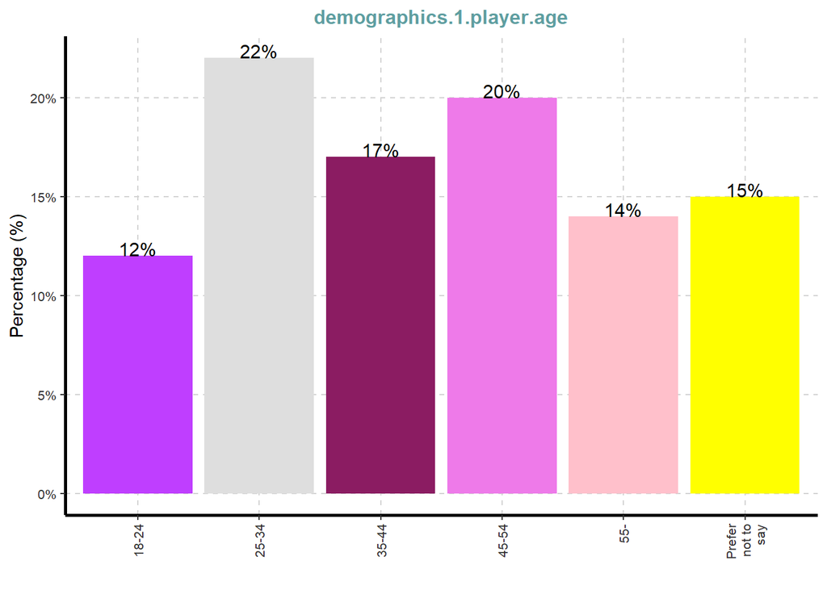

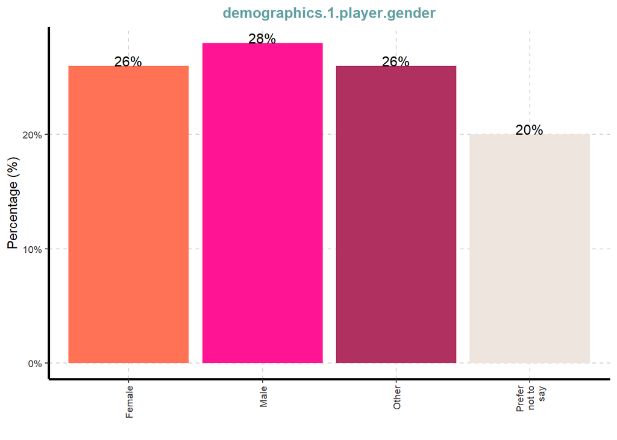

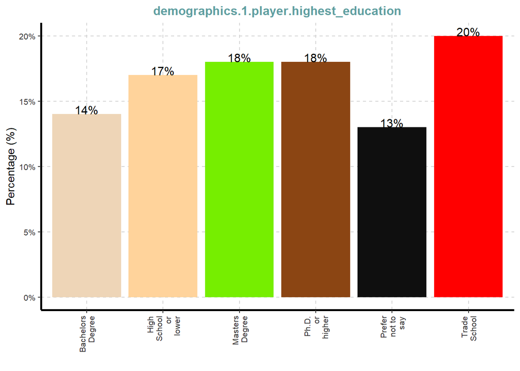

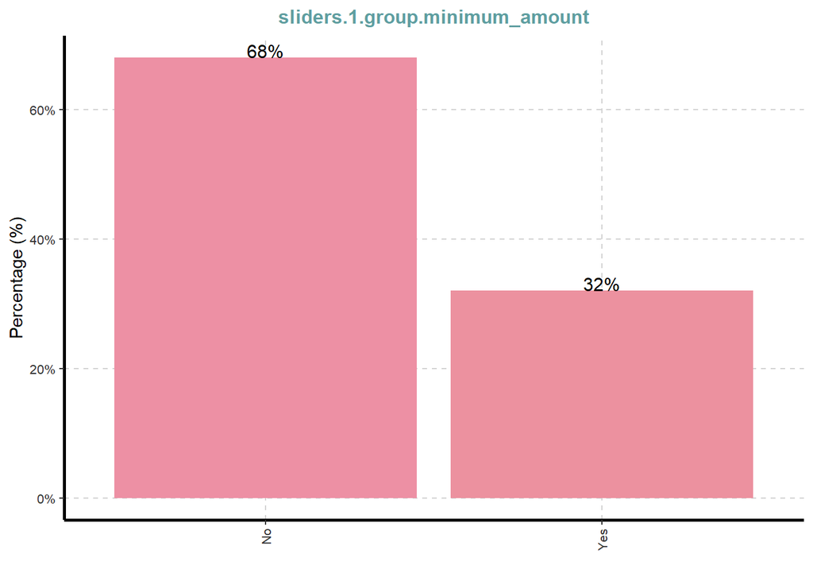

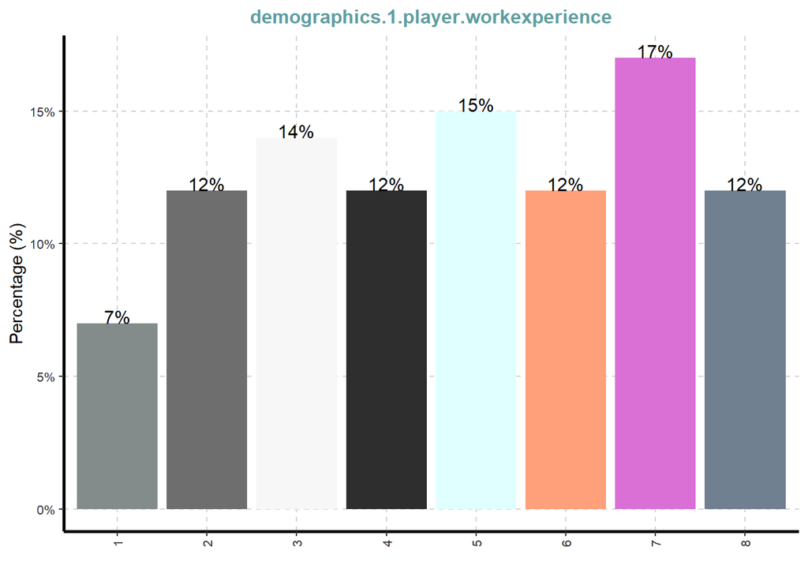

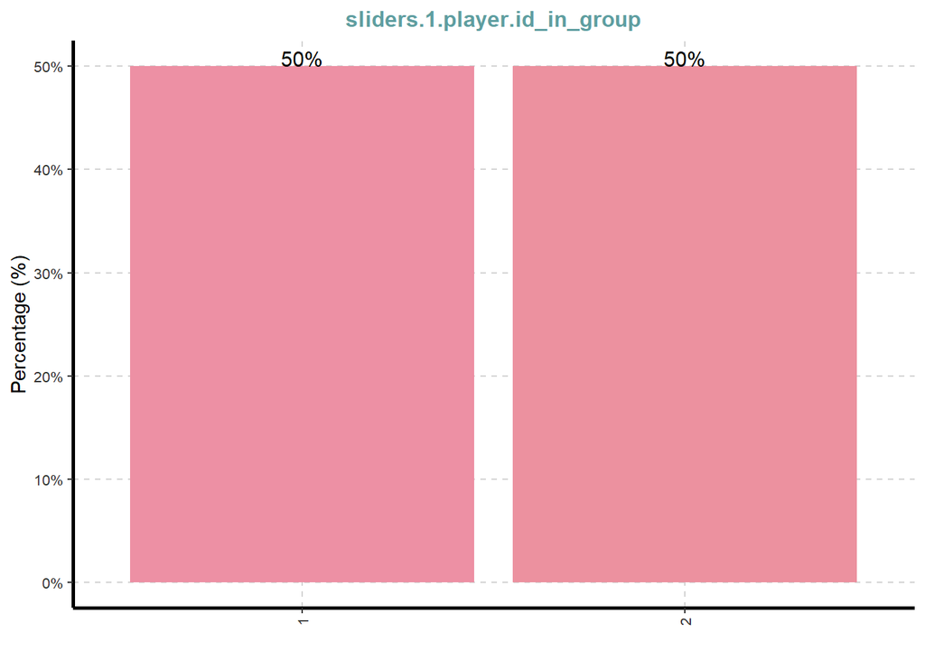

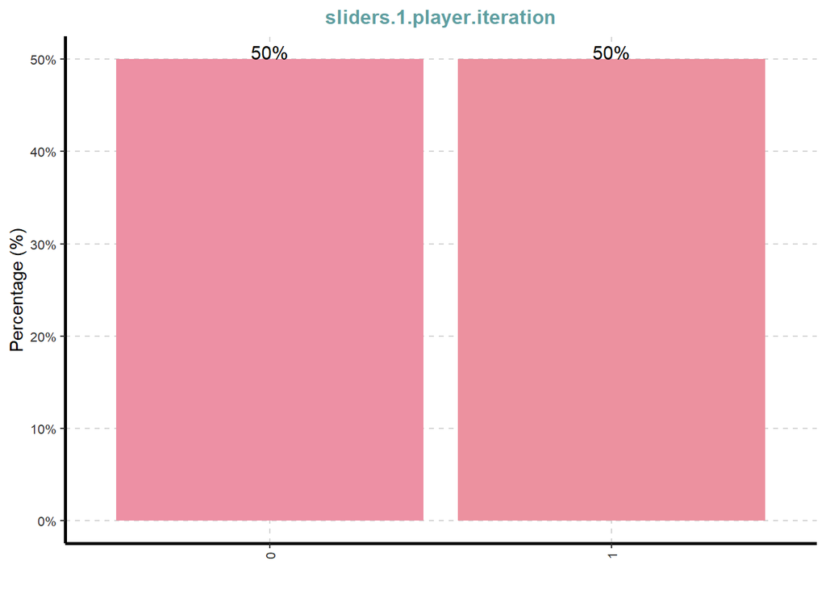

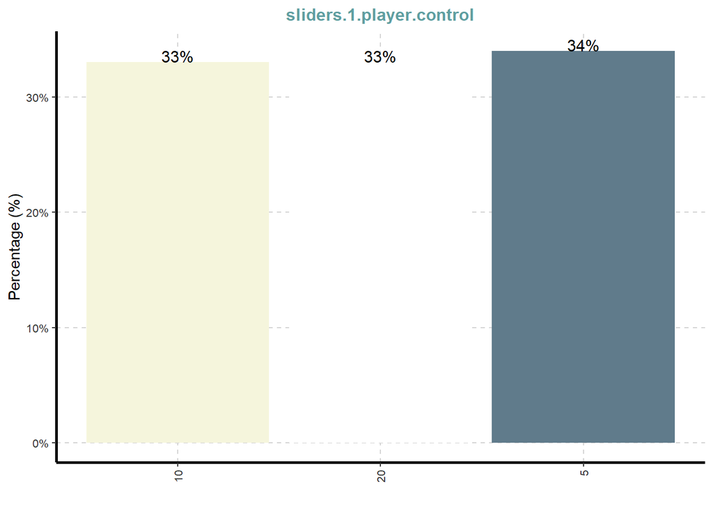

```r
ExpCatViz(sliders_df)
```

Some insight that can be drawn:

Let us see the how the chosen effort average is distributed along the age groups:

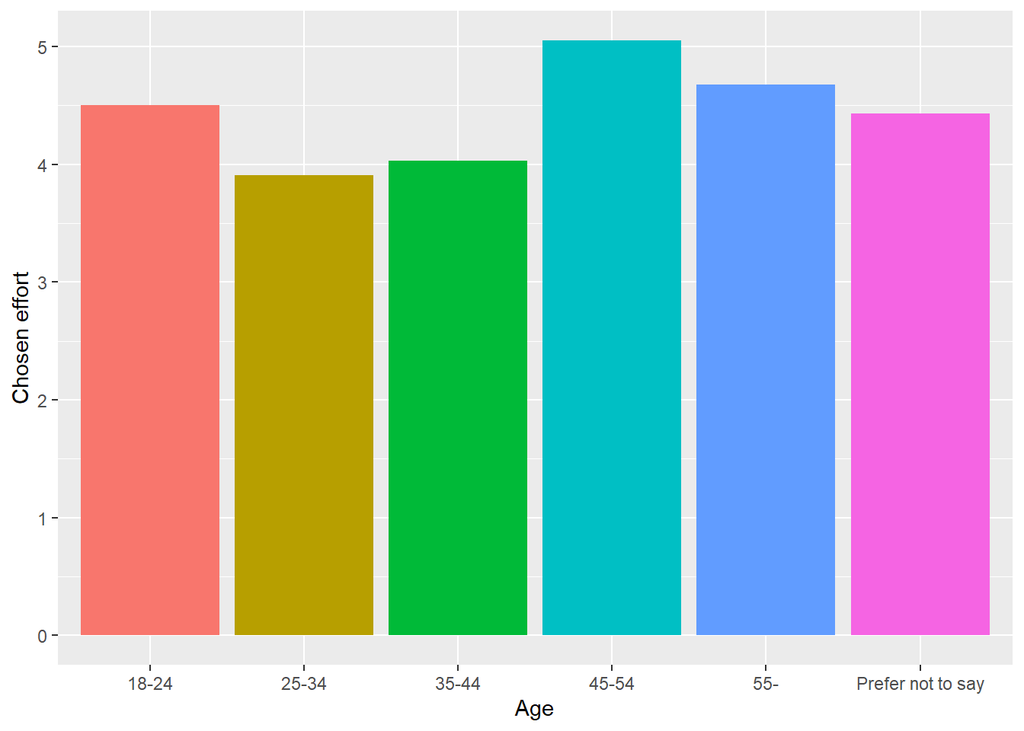

```r
df_demographics_sliders <- sliders_df %>%
  select(c(demographics.1.player.age,demographics.1.player.highest_education, demographics.1.player.gender, demographics.1.player.workexperience, sliders.1.group.chosen_effort))

ggplot(df_demographics_sliders) +
  geom_bar(aes(x=demographics.1.player.age, y=sliders.1.group.chosen_effort, fill = as.factor(demographics.1.player.age)),
           position = "dodge", stat = "summary", fun = "mean") +
  labs(x = "Age", y = "Chosen effort") +
  theme(legend.position="none")
```

We can notice that age group 25-34 showed below average mean choice of effort level.

Let’s have a look at the distribution of chosen effort across highest achieved education by participant:

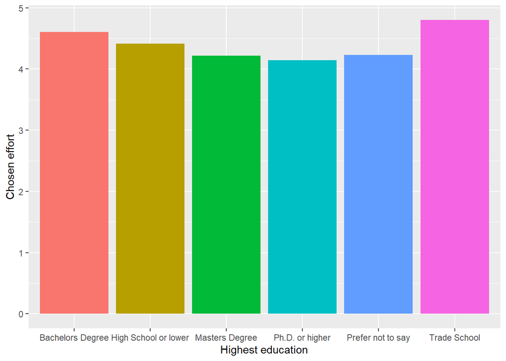

```r
ggplot(df_demographics_sliders) +
  geom_bar(aes(x=demographics.1.player.highest_education, y=sliders.1.group.chosen_effort, fill = as.factor(demographics.1.player.highest_education)),
           position = "dodge", stat = "summary", fun = "mean") +
  labs(x = "Highest education", y = "Chosen effort") +
  theme(legend.position="none")
```

Analyzing the same differences per gender, males show a slightly higher chosen effort mean.

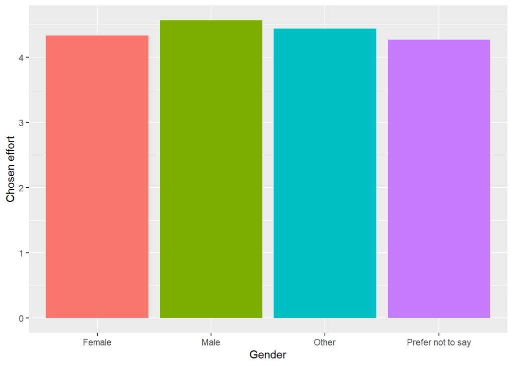

```r
ggplot(df_demographics_sliders) +
  geom_bar(aes(x=demographics.1.player.gender, y=sliders.1.group.chosen_effort, fill = as.factor(demographics.1.player.gender)),
           position = "dodge", stat = "summary", fun = "mean") +
  labs(x = "Gender", y = "Chosen effort") +
  theme(legend.position="none")
```

Next up, we can see that participants with 5 or more years of work experience show most mean effort provision.

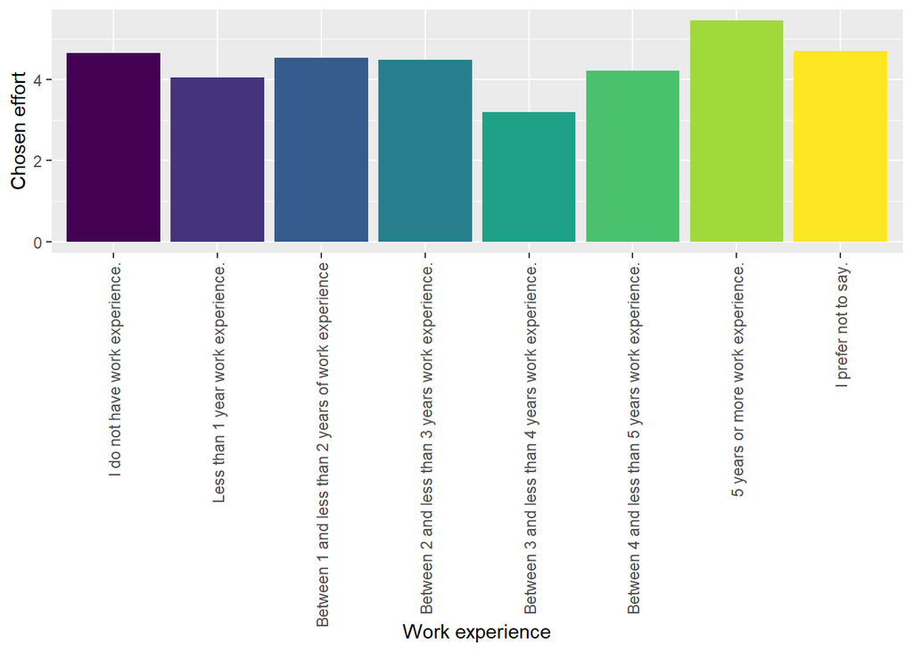

```r
factors_vector_sliders = c(
  "I do not have work experience.",
  "Less than 1 year work experience.",
  "Between 1 and less than 2 years of work experience",
  "Between 2 and less than 3 years work experience.",
  "Between 3 and less than 4 years work experience.",
  "Between 4 and less than 5 years work experience.",
  "5 years or more work experience.",
  "I prefer not to say."
  )
factors_df_sliders <- data.frame(V1=1:8, V2=factors_vector_sliders)

df_demographics_sliders <- within(df_demographics_sliders, {
  f <- factor(df_demographics_sliders$demographics.1.player.workexperience, levels=factors_df_sliders$V1, labels=factors_df_sliders$V2)
  demographics.1.player.workexperience <- as.character(f)
  })

df_demographics_sliders$demographics.1.player.workexperience <- as.character(df_demographics_sliders$demographics.1.player.workexperience)
df_demographics_sliders$demographics.1.player.workexperience <- ordered(df_demographics_sliders$demographics.1.player.workexperience, levels = factors_vector_sliders)

ggplot(df_demographics_sliders) +
  geom_bar(aes(x=demographics.1.player.workexperience, y=sliders.1.group.chosen_effort, fill = as.factor(demographics.1.player.workexperience)),
           position = "dodge", stat = "summary", fun = "mean") +
  labs(x = "Work experience", y = "Chosen effort") +
  theme(legend.position="none") +
  theme(axis.text.x = element_text(angle = 90, vjust = 0.5, hjust=1))
```

### Prepare data

Since the participants are split into principal/agent pairs, the dataset contains information about experiment values (chosen effort if not controlled, effort if controlled) in both rows - for the principal and the agent, essentially duplicating these data.

```r
head(sliders_df)
```

|  | participant.id_in_session | participant.code | participant.label | participant._is_bot | participant._index_in_pages | participant._max_page_index | participant._current_app_name | participant._current_page_name | participant.time_started_utc | participant.visited | participant.mturk_worker_id | participant.mturk_assignment_id | participant.payoff | participant.random_treatment_ids | session.code | session.label | session.mturk_HITId | session.mturk_HITGroupId | session.comment | session.is_demo | session.config.real_world_currency_per_point | session.config.participation_fee | session.config.name | session.params | informed_consent.1.player.id_in_group | informed_consent.1.player.role | informed_consent.1.player.payoff | informed_consent.1.player.consent_given | informed_consent.1.group.id_in_subsession | … |
| --- | --- | --- | --- | --- | --- | --- | --- | --- | --- | --- | --- | --- | --- | --- | --- | --- | --- | --- | --- | --- | --- | --- | --- | --- | --- | --- | --- | --- | --- | --- |
| 1 | 1 | jgvcs74e | NA | 0 | 13 | 13 | payment_info | PaymentInfo | 23:55.3 | 1 | NA | NA | 25 | NA | xuhmiv3r | NA | NA | NA | NA | 0 | 0.01 | 0.25 | sliders | {'trial_delay': 1.0, 'retry_delay': 0.1, 'num_sliders': 24, 'num_columns': 3, 'attempts_per_slider': 1} | 1 | NA | 0 | 1 | 1 | … |
| 2 | 2 | zsy9o8a7 | NA | 0 | 13 | 13 | payment_info | PaymentInfo | 23:55.7 | 1 | NA | NA | 40 | NA | xuhmiv3r | NA | NA | NA | NA | 0 | 0.01 | 0.25 | sliders | {'trial_delay': 1.0, 'retry_delay': 0.1, 'num_sliders': 24, 'num_columns': 3, 'attempts_per_slider': 1} | 2 | NA | 0 | 1 | 1 | … |
| 3 | 3 | qe7oqg6j | NA | 0 | 13 | 13 | payment_info | PaymentInfo | 35:22.2 | 1 | NA | NA | 15 | NA | xuhmiv3r | NA | NA | NA | NA | 0 | 0.01 | 0.25 | sliders | {'trial_delay': 1.0, 'retry_delay': 0.1, 'num_sliders': 24, 'num_columns': 3, 'attempts_per_slider': 1} | 3 | NA | 0 | 1 | 1 | … |
| 4 | 4 | fr75jufi | NA | 0 | 13 | 13 | payment_info | PaymentInfo | 35:22.6 | 1 | NA | NA | 40 | NA | xuhmiv3r | NA | NA | NA | NA | 0 | 0.01 | 0.25 | sliders | {'trial_delay': 1.0, 'retry_delay': 0.1, 'num_sliders': 24, 'num_columns': 3, 'attempts_per_slider': 1} | 4 | NA | 0 | 1 | 1 | … |
| 5 | 5 | pmq722s6 | NA | 0 | 13 | 13 | payment_info | PaymentInfo | 36:13.9 | 1 | NA | NA | 20 | NA | xuhmiv3r | NA | NA | NA | NA | 0 | 0.01 | 0.25 | sliders | {'trial_delay': 1.0, 'retry_delay': 0.1, 'num_sliders': 24, 'num_columns': 3, 'attempts_per_slider': 1} | 5 | NA | 0 | 1 | 1 | … |
| 6 | 6 | prxeqizk | NA | 0 | 13 | 13 | payment_info | PaymentInfo | 36:14.3 | 1 | NA | NA | 40 | NA | xuhmiv3r | NA | NA | NA | NA | 0 | 0.01 | 0.25 | sliders | {'trial_delay': 1.0, 'retry_delay': 0.1, 'num_sliders': 24, 'num_columns': 3, 'attempts_per_slider': 1} | 6 | NA | 0 | 1 | 1 | … |

Let us then have only agent rows in a separate dataframe

```r
sliders_df_agent <- sliders_df %>%
  filter(participant.id_in_session %% 2 == 0)
```

Apart from that, let’s separate each treatment into a dataframe for convenience

```r
sliders_c5 <- sliders_df_agent %>%
  filter(sliders.1.player.control == 5)
sliders_c5_trust <- sliders_c5 %>%
  filter(sliders.1.group.minimum_amount == "No")
sliders_c5_control <- sliders_c5 %>%
  filter(sliders.1.group.minimum_amount == "Yes")

sliders_c10 <- sliders_df_agent %>%
  filter(sliders.1.player.control == 10)
sliders_c10_trust <- sliders_c10 %>%
  filter(sliders.1.group.minimum_amount == "No")
sliders_c10_control <- sliders_c10 %>%
  filter(sliders.1.group.minimum_amount == "Yes")

sliders_c20 <- sliders_df_agent %>%
  filter(sliders.1.player.control == 20)
sliders_c20_trust <- sliders_c20 %>%
  filter(sliders.1.group.minimum_amount == "No")
sliders_c20_control <- sliders_c20 %>%
  filter(sliders.1.group.minimum_amount == "Yes")
```

Thus, in each dataframe, `sliders.1.group.chosen_effort` is the number of sliders done.

### Analysis

In this section we will be aiming to conduct several tests to understand if hidden costs of control are present in the results of the this experiment. The significance level $\alpha$ here and further on is chosen to be 5%.

Firstly, we will test if there is difference in effort provision in cases of controlling and not controlling, with the null hypothesis being that the groups are the same. This will be done by modifying chosen effort in no control scenario to always be above minimum amount (setting all those that are lower to a minimum amount).

```r
sliders_c5_trust <- sliders_c5_trust %>%
  mutate(sliders.1.group.chosen_effort_modified = ifelse(sliders.1.group.chosen_effort < 5, 5, sliders.1.group.chosen_effort))

wilcox.test(sliders_c5_trust$sliders.1.group.chosen_effort_modified, sliders_c5_control$sliders.1.group.chosen_effort, exact = F)
```

```
##
##  Wilcoxon rank sum test with continuity correction
##
## data:  sliders_c5_trust$sliders.1.group.chosen_effort_modified and sliders_c5_control$sliders.1.group.chosen_effort
## W = 240, p-value = 1.321e-06
## alternative hypothesis: true location shift is not equal to 0
```

Let’s look at the means of groups.

```r
mean(sliders_c5_control$sliders.1.group.chosen_effort)
```

```
## [1] 2.3
```

```r
mean(sliders_c5_trust$sliders.1.group.chosen_effort)
```

```
## [1] 4.041667
```

We can see that, as expected, mean effort provision with no control is higher.

Let’s test the same hypothesis for C10 treatment:

```r
sliders_c10_trust <- sliders_c10_trust %>%
  mutate(sliders.1.group.chosen_effort_modified = ifelse(sliders.1.group.chosen_effort < 10, 10, sliders.1.group.chosen_effort))

wilcox.test(sliders_c10_trust$sliders.1.group.chosen_effort_modified, sliders_c10_control$sliders.1.group.chosen_effort, exact = F)
```

```
##
##  Wilcoxon rank sum test with continuity correction
##
## data:  sliders_c10_trust$sliders.1.group.chosen_effort_modified and sliders_c10_control$sliders.1.group.chosen_effort
## W = 242, p-value = 3.712e-08
## alternative hypothesis: true location shift is not equal to 0
```

Again, the null hypothesis is rejected.

Having look at the means, no control has greater mean effort provision.

```r
mean(sliders_c10_control$sliders.1.group.chosen_effort)
```

```
## [1] 3.545455
```

```r
mean(sliders_c10_trust$sliders.1.group.chosen_effort_modified)
```

```
## [1] 10
```

Finally, test C20 treatment.

```r
sliders_c20_trust <- sliders_c20_trust %>%
  mutate(sliders.1.group.chosen_effort_modified = ifelse(sliders.1.group.chosen_effort < 20, 20, sliders.1.group.chosen_effort))

wilcox.test(sliders_c20_trust$sliders.1.group.chosen_effort_modified, sliders_c20_control$sliders.1.group.chosen_effort, exact = F)
```

```
##
##  Wilcoxon rank sum test with continuity correction
##
## data:  sliders_c20_trust$sliders.1.group.chosen_effort_modified and sliders_c20_control$sliders.1.group.chosen_effort
## W = 242, p-value = 3.838e-08
## alternative hypothesis: true location shift is not equal to 0
```

Again, we reject the null hypothesis.

The mean of effort provision is again greater for no control.

```r
mean(sliders_c20_control$sliders.1.group.chosen_effort)
```

```
## [1] 5.909091
```

```r
mean(sliders_c20_trust$sliders.1.group.chosen_effort_modified)
```

```
## [1] 20
```

Now, let us conduct the second test for these treatments. We will be testing if the hidden costs of control outweigh the benefits. That is, if effort provision is greater for no control situations even if no adjustment with setting values lesser than minimum amount to minimum amount is implemented.

```r
# C5
wilcox.test(sliders_c5_control$sliders.1.group.chosen_effort, sliders_c5_trust$sliders.1.group.chosen_effort, exact = F)
```

```
##
##  Wilcoxon rank sum test with continuity correction
##
## data:  sliders_c5_control$sliders.1.group.chosen_effort and sliders_c5_trust$sliders.1.group.chosen_effort
## W = 65, p-value = 0.03724
## alternative hypothesis: true location shift is not equal to 0
```

```r
# C10
wilcox.test(sliders_c10_control$sliders.1.group.chosen_effort, sliders_c10_trust$sliders.1.group.chosen_effort, exact = F)
```

```
##
##  Wilcoxon rank sum test with continuity correction
##
## data:  sliders_c10_control$sliders.1.group.chosen_effort and sliders_c10_trust$sliders.1.group.chosen_effort
## W = 63, p-value = 0.02633
## alternative hypothesis: true location shift is not equal to 0
```

```r
# C20
wilcox.test(sliders_c20_control$sliders.1.group.chosen_effort, sliders_c20_trust$sliders.1.group.chosen_effort, exact = F)
```

```
##
##  Wilcoxon rank sum test with continuity correction
##
## data:  sliders_c20_control$sliders.1.group.chosen_effort and sliders_c20_trust$sliders.1.group.chosen_effort
## W = 159, p-value = 0.1477
## alternative hypothesis: true location shift is not equal to 0
```

```r
mean(sliders_c5_control$sliders.1.group.chosen_effort)
```

```
## [1] 2.3
```

```r
mean(sliders_c5_trust$sliders.1.group.chosen_effort)
```

```
## [1] 4.041667
```

```r
median(sliders_c5_control$sliders.1.group.chosen_effort)
```

```
## [1] 2.5
```

```r
median(sliders_c5_trust$sliders.1.group.chosen_effort)
```

```
## [1] 4
```

```r
mean(sliders_c10_control$sliders.1.group.chosen_effort)
```

```
## [1] 3.545455
```

```r
mean(sliders_c10_trust$sliders.1.group.chosen_effort)
```

```
## [1] 5.181818
```

```r
median(sliders_c10_control$sliders.1.group.chosen_effort)
```

```
## [1] 4
```

```r
median(sliders_c10_trust$sliders.1.group.chosen_effort)
```

```
## [1] 5.5
```

```r
mean(sliders_c20_control$sliders.1.group.chosen_effort)
```

```
## [1] 5.909091
```

```r
mean(sliders_c20_trust$sliders.1.group.chosen_effort)
```

```
## [1] 4.681818
```

```r
median(sliders_c20_control$sliders.1.group.chosen_effort)
```

```
## [1] 6
```

```r
median(sliders_c20_trust$sliders.1.group.chosen_effort)
```

```
## [1] 4
```

## Experiment 3

```r
survey_df <- read.csv("data/survey.csv")
```

### Describe data

```r
ExpData(survey_df, type = 1)
```

| Descriptions | Value |
| --- | --- |
| Sample size (nrow) | 100 |
| No. of variables (ncol) | 170 |
| No. of numeric/interger variables | 138 |
| No. of factor variables | 0 |
| No. of text variables | 16 |
| No. of logical variables | 16 |
| No. of identifier variables | 10 |
| No. of date variables | 0 |
| No. of zero variance variables (uniform) | 76 |
| %. of variables having complete cases | 27.65% (47) |

[output cut: 3 more lines]

```r
ExpData(survey_df, type = 2)
```

| Index | Variable_Name | Variable_Type | Sample_n | Missing_Count | Per_of_Missing | No_of_distinct_values |
| --- | --- | --- | --- | --- | --- | --- |
| 1 | participant.id_in_session | integer | 100 | 0 | 0.00 | 100 |
| 2 | participant.code | character | 100 | 0 | 0.00 | 100 |
| 3 | participant.label | logical | 0 | 100 | 1.00 | 0 |
| 4 | participant._is_bot | integer | 100 | 0 | 0.00 | 1 |
| 5 | participant._index_in_pages | integer | 100 | 0 | 0.00 | 5 |
| 6 | participant._max_page_index | integer | 100 | 0 | 0.00 | 1 |
| 7 | participant._current_app_name | character | 56 | 44 | 0.44 | 5 |
| 8 | participant._current_page_name | character | 56 | 44 | 0.44 | 5 |
| 9 | participant.time_started_utc | character | 56 | 44 | 0.44 | 57 |
| 10 | participant.visited | integer | 100 | 0 | 0.00 | 2 |

[output cut: 160 more lines]

```r
ExpNumStat(survey_df, Outlier = TRUE, round = 2)
```

|  | Vname | Group | TN | nNeg | nZero | nPos | NegInf | PosInf | NA_Value | Per_of_Missing | sum | min | max | mean | median | SD | CV | IQR | Skewness | Kurtosis | LB.25% | UB.75% | nOutliers |
| --- | --- | --- | --- | --- | --- | --- | --- | --- | --- | --- | --- | --- | --- | --- | --- | --- | --- | --- | --- | --- | --- | --- | --- |
| 7 | demographics.1.player.id_in_group | All | 100 | 0 | 0 | 100 | 0 | 0 | 0 | 0 | 5050 | 1 | 100 | 50.5 | 50.5 | 29.01 | 0.57 | 49.5 | 0 | -1.2 | -48.5 | 149.5 | 0 |
| 8 | feedback.1.player.id_in_group | All | 100 | 0 | 0 | 100 | 0 | 0 | 0 | 0 | 5050 | 1 | 100 | 50.5 | 50.5 | 29.01 | 0.57 | 49.5 | 0 | -1.2 | -48.5 | 149.5 | 0 |
| 1 | participant.id_in_session | All | 100 | 0 | 0 | 100 | 0 | 0 | 0 | 0 | 5050 | 1 | 100 | 50.5 | 50.5 | 29.01 | 0.57 | 49.5 | 0 | -1.2 | -48.5 | 149.5 | 0 |
| 9 | payment_info.1.player.id_in_group | All | 100 | 0 | 0 | 100 | 0 | 0 | 0 | 0 | 5050 | 1 | 100 | 50.5 | 50.5 | 29.01 | 0.57 | 49.5 | 0 | -1.2 | -48.5 | 149.5 | 0 |
| 2 | survey.1.player.id_in_group | All | 100 | 0 | 0 | 100 | 0 | 0 | 0 | 0 | 5050 | 1 | 100 | 50.5 | 50.5 | 29.01 | 0.57 | 49.5 | 0 | -1.2 | -48.5 | 149.5 | 0 |
| 3 | survey.2.player.id_in_group | All | 100 | 0 | 0 | 100 | 0 | 0 | 0 | 0 | 5050 | 1 | 100 | 50.5 | 50.5 | 29.01 | 0.57 | 49.5 | 0 | -1.2 | -48.5 | 149.5 | 0 |
| 4 | survey.3.player.id_in_group | All | 100 | 0 | 0 | 100 | 0 | 0 | 0 | 0 | 5050 | 1 | 100 | 50.5 | 50.5 | 29.01 | 0.57 | 49.5 | 0 | -1.2 | -48.5 | 149.5 | 0 |
| 5 | survey.4.player.id_in_group | All | 100 | 0 | 0 | 100 | 0 | 0 | 0 | 0 | 5050 | 1 | 100 | 50.5 | 50.5 | 29.01 | 0.57 | 49.5 | 0 | -1.2 | -48.5 | 149.5 | 0 |
| 6 | survey.5.player.id_in_group | All | 100 | 0 | 0 | 100 | 0 | 0 | 0 | 0 | 5050 | 1 | 100 | 50.5 | 50.5 | 29.01 | 0.57 | 49.5 | 0 | -1.2 | -48.5 | 149.5 | 0 |

### Clean data

Roughly half of the rows in the dataset is related to participants who have not started the survey, thus:

```r
survey_df <- survey_df %>%
  filter(participant.visited == 1)
```